# First Differences

Anna Werner & Susumu Shikano

2024-03-29

## Load data

```r
load("Data/analysis_dat.RData")
```

## Switch for party selection and spill over

```r
party.selec.switch <-1
spill.over.switch <-0 # 1: with spill over
turnout.switch <- 0 # 1: turnout analysis
```

See below what value corresponds to what party selection.

```r
## Do not select only one party. This won't work!

if (party.selec.switch==1) party.selection <- c(1:6)      # C S A F L G
if (party.selec.switch==2) party.selection <- c(1:2,6)      # nur C und S + G (2021)
if (party.selec.switch==3) party.selection <- c(3:6)      # ohne C und S und G (2021)
if (party.selec.switch==4) party.selection <- c(2:6)      # ohne C
if (party.selec.switch==5) party.selection <- c(1,3:6)    # ohne S
if (party.selec.switch==6) party.selection <- c(1:3,5:6) # ohne F
if (party.selec.switch==7) party.selection <- c(1:4,6)    # ohne Linke
if (party.selec.switch==8) party.selection <- c(1:5)     # ohne G
if (party.selec.switch==9) party.selection <- c(1:2,4:6)  # ohne AfD
if (party.selec.switch==10) party.selection <- c(2,4:6)    # ohne C und A
if (party.selec.switch==11) party.selection <- c(3:4,6)    # ohne C, S und L
```

Reading adjacent matrix

```r
if (spill.over.switch>0){
  load("Data/btw_all_shape.RData")
  all.nb.mat <- all.nb.mat[3:7]
}
```

## Switch for denominator to compute the vote share

1: eligible citizens (for turnout in analysis, this option has to be selected.) 2: all voters 3: all valid votes

```r
vote.denom <- 1
if (turnout.switch==1) vote.denom <- 1
```

all.abs.votes has 5 dimensions:

- 299 districts
- 6 parties
- tier: FPTP or PR
- 6 elections
- current or last elections

all.treat has 4 dimensions:

- 299 districts
- 6 parties
- tier: FPTP or PR
- 6 elections

```r
if (turnout.switch==0){
  all.abs.votes <- all.abs.votes[,party.selection,,,]
  all.treat     <- all.treat[,party.selection,,]
  all.rel.votes <-  all.abs.votes/
  all.abs.total[,rep(vote.denom,length(party.selection)),,,,drop=F]
}else{
  all.abs.votes <- all.abs.total[,2,,,,drop=F]
  all.treat     <- all.treat[,party.selection,,]
  temp <- apply(all.treat,c(1,3,4),max)
  all.treat <- array(temp,dim=c(299,1,2,6))
  all.rel.votes <-  all.abs.votes/all.abs.total[,rep(vote.denom,1),,,,drop=F]
}
```

## Creating first difference

### Election results

We create the first differences:

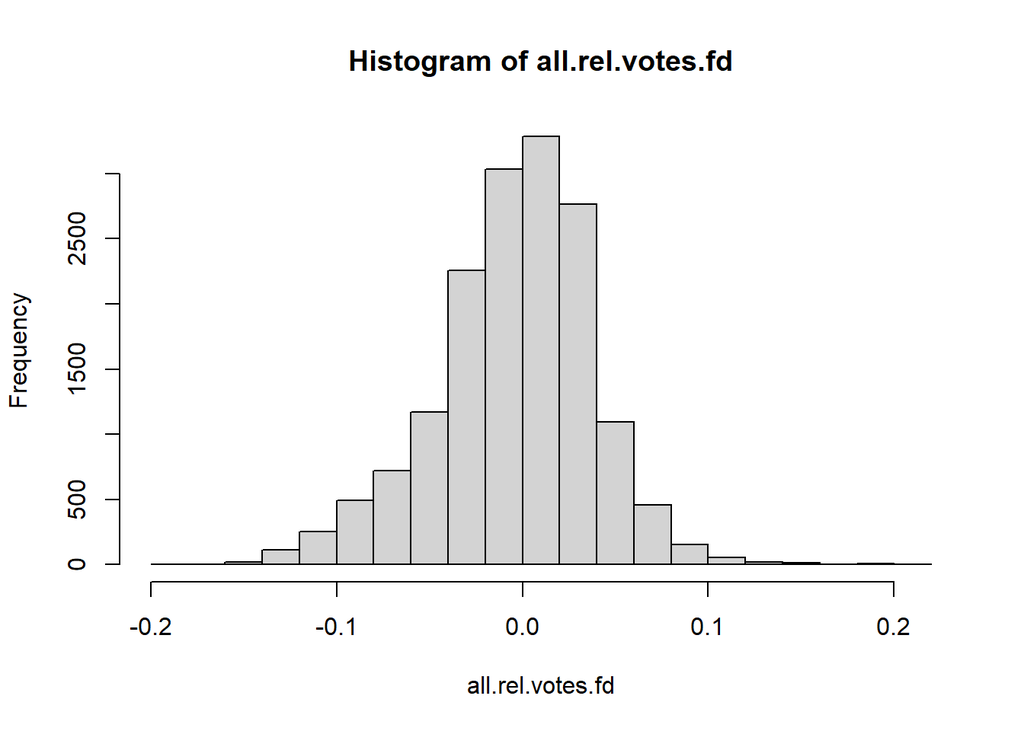

```r
  all.rel.votes.fd <- all.rel.votes[,,,1:5,1,drop=F] - all.rel.votes[,,,1:5,2,drop=F]
  # Note that there will be no FD for 2002, therefore we have n(year)=5.
    all.rel.votes.fd <- array(all.rel.votes.fd,
                              dim=dim(all.rel.votes.fd)[1:4])

  hist(all.rel.votes.fd)
```

### Treatment

Treatment leading candidate or not

```r
# Make all values >0 to 1
all.treat.dummy <- all.treat
all.treat.dummy[all.treat.dummy>0] <- 1

all.treat.incumb <- ifelse(all.treat==3|all.treat==4,1,0)

table(all.treat.dummy)
```

```
## all.treat.dummy
##     0     1
## 20545   983
```

```r
apply(all.treat.dummy,3,table)
```

```
##    [,1] [,2]
## 0 10724 9821
## 1    40  943
```

```r
table(all.treat.incumb)
```

```
## all.treat.incumb
##     0     1
## 21147   381
```

```r
apply(all.treat.incumb,3,table)
```

```
##    [,1]  [,2]
## 0 10751 10396
## 1    13   368
```

```r
if (turnout.switch==0){
  all.treat.dummy.fd <-
  all.treat.incumb.fd <-
      array(NA,dim=c(299,length(party.selection),2,5))
}else{
  all.treat.dummy.fd <-
  all.treat.incumb.fd <-
      array(NA,dim=c(299,1,2,5))
}

for (i.time in 1:5){ # loop over time
  all.treat.dummy.fd[,,,i.time] <-
    all.treat.dummy[,,,i.time] - all.treat.dummy[,,,i.time+1]

  all.treat.incumb.fd[,,,i.time] <-
    all.treat.incumb[,,,i.time] - all.treat.incumb[,,,i.time+1]

}

table(all.treat.dummy.fd)
```

```
## all.treat.dummy.fd
##    -1     0     1
##   461 16827   652
```

```r
apply(all.treat.dummy.fd,3,table)
```

```
##    [,1] [,2]
## -1   22  439
## 0  8921 7906
## 1    27  625
```

```r
table(all.treat.incumb.fd)
```

```
## all.treat.incumb.fd
##    -1     0     1
##   219 17419   302
```

```r
apply(all.treat.incumb.fd,3,table)
```

```
##    [,1] [,2]
## -1    7  212
## 0  8953 8466
## 1    10  292
```

The resulting all.treat.dummy.fd has: - 299 districts - 6 parties - 2 tiers - 5 timepoints

Incomporting spill-over treatment

```r
if (spill.over.switch>0){
  for (i.tier in 1:2){
  for (i.btw in c(1:5)){
      temp.treat <- all.treat.dummy.fd[,,i.tier,i.btw]
      temp.mat <- as.matrix(all.nb.mat[[6-i.btw]])
      diag(temp.mat) <- 1 # replace the diagonal elements with 1
      spill.treat <- temp.mat%*%temp.treat

      spill.treat[spill.treat>0] <- 1
      spill.treat[spill.treat<0] <- -1
      all.treat.dummy.fd[,,i.tier,i.btw] <- spill.treat
  }
}}

apply(all.treat.dummy.fd,3,table)
```

```
##    [,1] [,2]
## -1   22  439
## 0  8921 7906
## 1    27  625
```

## index array

Year index

```r
year.index <- all.treat.dummy.fd

year.index[,,,1] <- 2021
year.index[,,,2] <- 2017
year.index[,,,3] <- 2013
year.index[,,,4] <- 2009
year.index[,,,5] <- 2005

table(year.index)
```

```
## year.index
## 2005 2009 2013 2017 2021
## 3588 3588 3588 3588 3588
```

Party index

```r
party.index <- all.treat.dummy.fd

if(turnout.switch==0){
    party.labels <- c("CDU","SPD","AFD","FDP","LIN","GRU")[party.selection]
    for (i.party in 1:length(party.selection)){
      party.index[,i.party,,] <- party.labels[i.party]
    }}else{
  party.labels <- "Turnout"
  party.index[,1,,] <- party.labels
}


table(party.index)
```

```
## party.index
##  AFD  CDU  FDP  GRU  LIN  SPD
## 2990 2990 2990 2990 2990 2990
```

### Special treatment of Greens (2021)

```r
if (party.selec.switch==2) {
  all.rel.votes.fd[party.index=="GRU" & year.index!=2021] <-NA
}
if (party.selec.switch==3) {
  all.rel.votes.fd[party.index=="GRU" & year.index==2021] <-NA
}
```

## First difference models

```r
library(sandwich)
library(lmtest)
for (i.smdpr in 1:2){ # Loop over Erst- and Zweitstimme

  all.results <- vector("list",5) # empty list to store the results

  votes.in.array <- all.rel.votes.fd[,,i.smdpr,]
  votes <- c(all.rel.votes.fd[,,i.smdpr,] )
  treat <- c(all.treat.dummy.fd[,,i.smdpr,] )
  treat.incumb <- c(all.treat.incumb.fd[,,i.smdpr,] )
  year  <- as.factor(c(year.index[,,i.smdpr,] ))
  year <- relevel(year,ref="2005")
  party <- factor(c(party.index[,,i.smdpr,] ),
                  levels=c("CDU","SPD","AFD","FDP","LIN","GRU","Turnout")) # C S A F L G
  party <- relevel(party,ref="AFD")
  cross.treat <- c(all.treat.dummy.fd[,,c(2,1)[i.smdpr],] )
  cross.treat.incumb <- c(all.treat.incumb.fd[,,c(2,1)[i.smdpr],] )


  lm.dat <- cbind(votes,treat,cross.treat,treat.incumb,cross.treat.incumb)
  lm.dat <- as.data.frame(lm.dat)
  lm.dat$year <- year
  lm.dat$party <- party
  lm.dat <- na.omit(lm.dat)

  ## Model

  print(c("DV: Erststimme","DV: Zweitstimme")[i.smdpr])
  if (turnout.switch==0){
      print(summary(lm.out <- lm(votes~ treat +
                                    #treat.incumb + # control for Incumbency
                                    cross.treat +
                                    #cross.treat.incumb +
                                    year + year:party
                                    ,data=lm.dat)))
  }else{
          print(summary(lm.out <- lm(votes~ treat +
                                    #treat.incumb + # control for Incumbency
                                    cross.treat +
                                    #cross.treat.incumb +
                                    year
                                    ,data=lm.dat)))
  }

  print(c("Robust standard error"))
  r.se <- sqrt(diag(vcovHC(lm.out, type = 'HC')))
  print(lm.out.robust <- coeftest(lm.out, vcov = vcovHC(lm.out, type = 'HC')))


  all.results[[1]] <- lm.out

  all.results[[2]] <- lm.out.robust

  all.results[[3]] <- lm.dat
  all.results[[4]] <- votes.in.array

  all.results[[5]] <- r.se

  if (i.smdpr==1) all.results.smd <- all.results
  if (i.smdpr==2) all.results.pr <- all.results
}
```

```
## [1] "DV: Erststimme"
##
## Call:
## lm(formula = votes ~ treat + cross.treat + year + year:party,
##     data = lm.dat)
##
## Residuals:
##       Min        1Q    Median        3Q       Max
## -0.144588 -0.009385  0.000093  0.009455  0.143351
##
## Coefficients: (3 not defined because of singularities)
##                     Estimate Std. Error t value Pr(>|t|)
## (Intercept)       -0.0032546  0.0011262  -2.890 0.003863 **
## treat              0.0145131  0.0028551   5.083 3.80e-07 ***
## cross.treat        0.0042483  0.0006471   6.565 5.54e-11 ***
## year2009           0.0259823  0.0015927  16.313  < 2e-16 ***
## year2013          -0.0103263  0.0015908  -6.491 9.04e-11 ***
## year2017           0.0558620  0.0019220  29.065  < 2e-16 ***
## year2021          -0.0072936  0.0016171  -4.510 6.57e-06 ***
## year2005:partyCDU -0.0056390  0.0015863  -3.555 0.000381 ***
## year2009:partyCDU -0.0609313  0.0015880 -38.370  < 2e-16 ***
## year2013:partyCDU  0.0581777  0.0015847  36.713  < 2e-16 ***
## year2017:partyCDU -0.0918043  0.0019193 -47.831  < 2e-16 ***
## year2021:partyCDU -0.0542560  0.0016217 -33.456  < 2e-16 ***
## year2005:partySPD -0.0300174  0.0015866 -18.919  < 2e-16 ***
## year2009:partySPD -0.1217277  0.0015875 -76.678  < 2e-16 ***
## year2013:partySPD  0.0255147  0.0015894  16.054  < 2e-16 ***
## year2017:partySPD -0.0747860  0.0019193 -38.965  < 2e-16 ***
## year2021:partySPD  0.0260765  0.0016043  16.254  < 2e-16 ***
## year2005:partyFDP -0.0067548  0.0015887  -4.252 2.14e-05 ***
## year2009:partyFDP  0.0071503  0.0015880   4.503 6.81e-06 ***
## year2013:partyFDP -0.0345396  0.0015892 -21.734  < 2e-16 ***
## year2017:partyFDP -0.0173412  0.0019180  -9.041  < 2e-16 ***
## year2021:partyFDP  0.0237962  0.0016080  14.798  < 2e-16 ***
## year2005:partyLIN  0.0311551  0.0016296  19.119  < 2e-16 ***
## year2009:partyLIN -0.0057636  0.0016026  -3.597 0.000324 ***
## year2013:partyLIN -0.0071808  0.0016064  -4.470 7.93e-06 ***
## year2017:partyLIN -0.0448913  0.0019276 -23.289  < 2e-16 ***
## year2021:partyLIN -0.0155063  0.0016101  -9.631  < 2e-16 ***
## year2005:partyGRU         NA         NA      NA       NA
```

[output cut: 120 more lines]

```
## year2021:partySPD  0.05717653  0.00133264  42.9046 < 2.2e-16 ***
## year2005:partyFDP  0.02140419  0.00100939  21.2052 < 2.2e-16 ***
## year2009:partyFDP  0.01461720  0.00081279  17.9839 < 2.2e-16 ***
## year2013:partyFDP -0.05163274  0.00105386 -48.9937 < 2.2e-16 ***
## year2017:partyFDP -0.01503946  0.00210678  -7.1386 1.025e-12 ***
## year2021:partyFDP  0.02110580  0.00099016  21.3156 < 2.2e-16 ***
## year2005:partyLIN  0.04061197  0.00127945  31.7417 < 2.2e-16 ***
## year2009:partyLIN  0.00557631  0.00082952   6.7223 1.911e-11 ***
## year2013:partyLIN -0.00898750  0.00082018 -10.9580 < 2.2e-16 ***
## year2017:partyLIN -0.05059841  0.00224130 -22.5755 < 2.2e-16 ***
## year2021:partyLIN -0.01634157  0.00103745 -15.7516 < 2.2e-16 ***
## year2017:partyGRU -0.05375985  0.00209198 -25.6981 < 2.2e-16 ***
## year2021:partyGRU  0.06098219  0.00159569  38.2167 < 2.2e-16 ***
## ---
## Signif. codes:  0 '***' 0.001 '**' 0.01 '*' 0.05 '.' 0.1 ' ' 1
```

```r
save(all.results.smd,
     all.results.pr,
  file=paste0("Data/Estimation_Results_PSelect",party.selec.switch,
             "_denom",vote.denom,
             c("","_spillover")[spill.over.switch+1],
             c("","_turnout")[turnout.switch+1],
             ".RData"))
```

```r
if (turnout.switch==1|spill.over.switch==1) knitr::knit_exit()
```

### Diagnostics I: Serial correlated errors

We regress u_t on u_t-1. If the effect is significant, there are serially correlated errors.

Note: We first have to assign individual districts at t to those at t-1.

```
## [1] "Erststimme"
##
## Call:
## lm(formula = c(current.resid) ~ c(past.resid))
##
## Residuals:
##       Min        1Q    Median        3Q       Max
## -0.144870 -0.009538  0.000370  0.009864  0.135041
##
## Coefficients:
##                 Estimate Std. Error t value Pr(>|t|)
## (Intercept)   -0.0001470  0.0002351  -0.625    0.532
## c(past.resid)  0.0110329  0.0125681   0.878    0.380
##
## Residual standard error: 0.01958 on 6934 degrees of freedom
##   (240 Beobachtungen als fehlend gelöscht)
## Multiple R-squared:  0.0001111,  Adjusted R-squared:  -3.308e-05
## F-statistic: 0.7706 on 1 and 6934 DF,  p-value: 0.3801
```

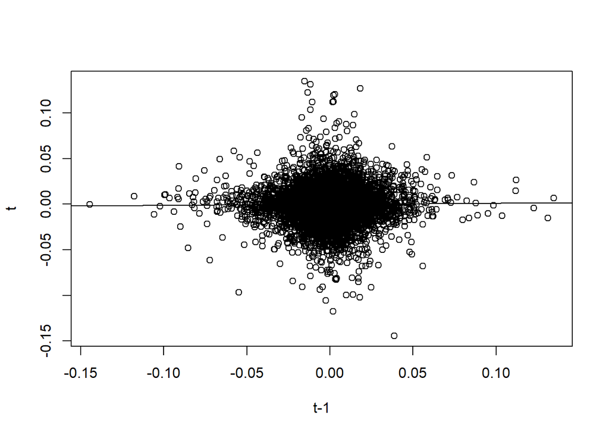

```
## [1] "Zweitstimme"
##
## Call:
## lm(formula = c(current.resid) ~ c(past.resid))
##
## Residuals:
##       Min        1Q    Median        3Q       Max
## -0.112312 -0.009117  0.000802  0.009263  0.154110
##
## Coefficients:
##                 Estimate Std. Error t value Pr(>|t|)
## (Intercept)    7.729e-05  2.201e-04   0.351 0.725426
## c(past.resid) -4.055e-02  1.224e-02  -3.314 0.000924 ***
## ---
## Signif. codes:  0 '***' 0.001 '**' 0.01 '*' 0.05 '.' 0.1 ' ' 1
##
## Residual standard error: 0.01833 on 6934 degrees of freedom
##   (240 Beobachtungen als fehlend gelöscht)
## Multiple R-squared:  0.001582,   Adjusted R-squared:  0.001438
## F-statistic: 10.98 on 1 and 6934 DF,  p-value: 0.0009237
```

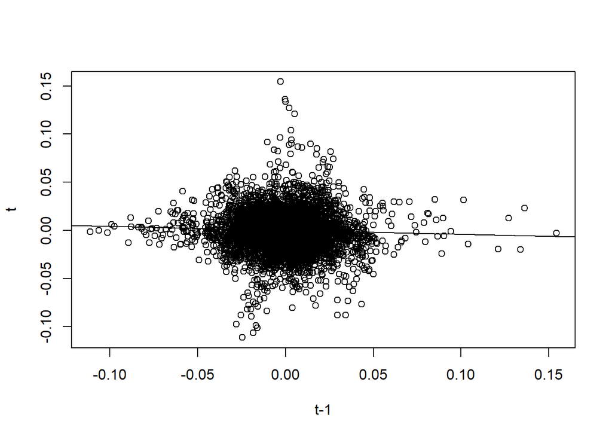

```r
for (i.smdpr in 1:2){
  if (i.smdpr==1){
    to.be.tested <- all.results.smd[[1]]  # Diagnostics for the model Erststimme
    temp.dat <- all.results.smd[[3]]
    temp.depv <- all.results.smd[[4]]

  }else{
    to.be.tested <- all.results.pr[[1]]  # Diagnostics for the model Zweitstimme
    temp.dat <- all.results.pr[[3]]
    temp.depv <- all.results.pr[[4]]
  }


residuals <- residuals(to.be.tested)

if (party.selec.switch!=0){
  residuals <- array(residuals,dim=dim(temp.depv))
}else{
  residuals <- array(residuals,
                     dim=c(dim(temp.depv)[1],1,dim(temp.depv)[2]))
}


simple.district.idx <- all.wkr.index[,1,1,]

# stacking residuals at t and t-1
## loop from BTW 2021 to 2009
current.resid <- past.resid <- residuals[,,1:4,drop=F]

for (i.btw in 1:4){
  # create the key to match the current and past districts
  key <- match(simple.district.idx[,i.btw],simple.district.idx[,i.btw+1])
  past.resid[,,i.btw] <- residuals[key,,i.btw+1]
}

print(c("Erststimme","Zweitstimme")[i.smdpr])
print(
   summary(lm.out <- lm(c(current.resid) ~ c(past.resid)))
)
plot(c(current.resid) ~ c(past.resid),
     ylab="t",xlab="t-1")
abline(lm.out)

}
```

### Diagnostics II: Exogeneity of the treatment

We are testing by using Wooldridge’s test. That is, we include the treatment variable at t+1. For this purpose, we lose the most recent BTW 2021.

Also here, we have to take care about the redistricting.

```r
for (i.smdpr in 1:2){ # Loop over Erst- and Zweitstimme

  all.results.t1 <- vector("list",3) # empty list to store the results

  votes.in.array <- all.rel.votes.fd[,,i.smdpr,2:5]
  votes <- c(votes.in.array)
  treat <- c(all.treat.dummy.fd[,,i.smdpr,2:5] )
  treat.incumb <- c(all.treat.incumb.fd[,,i.smdpr,2:5] )
  year  <- as.factor(c(year.index[,,i.smdpr,2:5] ))
  year <- relevel(year,ref="2005")
  party <- factor(c(party.index[,,i.smdpr,2:5] ),
                  levels=c("CDU","SPD","AFD","FDP","LIN","GRU")) # C S A F L G
  party <- relevel(party,ref="AFD")
  cross.treat <- c(all.treat.dummy.fd[,,c(2,1)[i.smdpr],2:5] )
  cross.treat.incumb <- c(all.treat.incumb.fd[,,c(2,1)[i.smdpr],2:5] )

  # treatment at t+1
  treat.t1 <- all.treat.dummy.fd[,,i.smdpr,1:4,drop=F]
  treat.t1 <- array(treat.t1,dim=dim(treat.t1)[c(1,2,4)])
  treat.incumb.t1 <- all.treat.incumb.fd[,,i.smdpr,1:4,drop=F]
  treat.incumb.t1 <- array(treat.incumb.t1,dim=dim(treat.incumb.t1)[c(1,2,4)])
  cross.treat.t1 <- all.treat.dummy.fd[,,c(2,1)[i.smdpr],1:4,drop=F]
  cross.treat.t1 <- array(cross.treat.t1,dim=dim(cross.treat.t1)[c(1,2,4)])
  cross.treat.incumb.t1 <- all.treat.incumb.fd[,,c(2,1)[i.smdpr],1:4,drop=F]
  cross.treat.incumb.t1 <- array(cross.treat.incumb.t1,dim=dim(cross.treat.incumb.t1)[c(1,2,4)])

  # we assign the correct district
  simple.district.idx <- all.wkr.index[,1,1,]
  for (i.btw in 2:5){ # loop over btw2017 to btw2005
    key <- match(simple.district.idx[,i.btw],simple.district.idx[,i.btw-1])
    treat.t1[,,i.btw-1] <- treat.t1[key,,i.btw-1]
    treat.incumb.t1[,,i.btw-1] <- treat.incumb.t1[key,,i.btw-1]
    cross.treat.t1[,,i.btw-1] <- cross.treat.t1[key,,i.btw-1]
    cross.treat.incumb.t1[,,i.btw-1] <- cross.treat.incumb.t1[key,,i.btw-1]
  }
  treat.t1 <- c(treat.t1)
  cross.treat.t1 <- c(cross.treat.t1)
  treat.incumb.t1 <- c(treat.incumb.t1)
  cross.treat.incumb.t1 <- c(cross.treat.incumb.t1)

  lm.dat <- cbind(votes,treat,year,party,
                  cross.treat,treat.incumb, cross.treat.incumb,
                  treat.t1,cross.treat.t1,treat.incumb.t1, cross.treat.incumb.t1)
  lm.dat <- as.data.frame(lm.dat)

  ## Model with cross treatment (contamination)

  print(c("DV: Erststimme","DV: Zweitstimme")[i.smdpr])
  if (party.selec.switch!=0){
      print(summary(lm.out <- lm(votes~ treat + treat.t1 +
                                    #treat.incumb +
                                    #treat.incumb.t1 +# control for Incumbency
                                    cross.treat + cross.treat.t1 +
                                    #cross.treat.incumb + cross.treat.incumb.t1 +
                               as.factor(year) + as.factor(year):as.factor(party),
                             data=lm.dat)))
  }else{
      print(summary(lm.out <- lm(votes~ treat + treat.t1 +
                                    #treat.incumb +
                                    #treat.incumb.t1 +# control for Incumbency
                                    cross.treat + cross.treat.t1 +
                                    #cross.treat.incumb + cross.treat.incumb.t1 +
                               as.factor(year) + as.factor(year),
                             data=lm.dat)))
  }

  print(c("Robust standard error"))
  r.se <- sqrt(diag(vcovHC(lm.out, type = 'HC')))
  print(lm.out.robust <- coeftest(lm.out, vcov = vcovHC(lm.out, type = 'HC')))

  print(c("Treatments Erststimmen","Treatments Zweitstimmen")[i.smdpr])
        print(table(treat))
        print(table(treat.t1))
        print(table(cross.treat))
        print(table(cross.treat.t1))


  all.results.t1[[1]] <- lm.out

  all.results.t1[[2]] <- lm.out.robust

  all.results.t1[[3]] <- lm.dat
  all.results.t1[[4]] <- votes.in.array

  all.results.t1[[5]] <- r.se

  if (i.smdpr==1) all.results.t1.smd <- all.results.t1
  if (i.smdpr==2) all.results.t1.pr <- all.results.t1
}
```

```
## [1] "DV: Erststimme"
##
## Call:
## lm(formula = votes ~ treat + treat.t1 + cross.treat + cross.treat.t1 +
##     as.factor(year) + as.factor(year):as.factor(party), data = lm.dat)
##
## Residuals:
##       Min        1Q    Median        3Q       Max
## -0.144346 -0.008768  0.000322  0.009378  0.145986
##
## Coefficients: (3 not defined because of singularities)
##                                      Estimate Std. Error t value Pr(>|t|)
## (Intercept)                        -0.0035982  0.0011333  -3.175 0.001507 **
## treat                               0.0127122  0.0031747   4.004 6.30e-05 ***
## treat.t1                           -0.0002578  0.0030559  -0.084 0.932781
## cross.treat                         0.0031902  0.0008392   3.802 0.000145 ***
## cross.treat.t1                      0.0003621  0.0007275   0.498 0.618632
## as.factor(year)2                    0.0267347  0.0015861  16.856  < 2e-16 ***
## as.factor(year)3                   -0.0100436  0.0015818  -6.349 2.32e-10 ***
## as.factor(year)4                    0.0564178  0.0018890  29.867  < 2e-16 ***
## as.factor(year)1:as.factor(party)2 -0.0051514  0.0015953  -3.229 0.001249 **
## as.factor(year)2:as.factor(party)2 -0.0624727  0.0015671 -39.865  < 2e-16 ***
## as.factor(year)3:as.factor(party)2  0.0579962  0.0015550  37.297  < 2e-16 ***
## as.factor(year)4:as.factor(party)2 -0.0922117  0.0018723 -49.251  < 2e-16 ***
## as.factor(year)1:as.factor(party)3 -0.0289287  0.0015953 -18.133  < 2e-16 ***
## as.factor(year)2:as.factor(party)3 -0.1220037  0.0015714 -77.638  < 2e-16 ***
## as.factor(year)3:as.factor(party)3  0.0261228  0.0015649  16.693  < 2e-16 ***
## as.factor(year)4:as.factor(party)3 -0.0748042  0.0018622 -40.170  < 2e-16 ***
## as.factor(year)1:as.factor(party)4 -0.0066987  0.0015985  -4.191 2.82e-05 ***
## as.factor(year)2:as.factor(party)4  0.0071205  0.0015733   4.526 6.13e-06 ***
## as.factor(year)3:as.factor(party)4 -0.0348159  0.0015615 -22.296  < 2e-16 ***
## as.factor(year)4:as.factor(party)4 -0.0173348  0.0018619  -9.310  < 2e-16 ***
## as.factor(year)1:as.factor(party)5  0.0304069  0.0016419  18.519  < 2e-16 ***
## as.factor(year)2:as.factor(party)5 -0.0064636  0.0015998  -4.040 5.41e-05 ***
## as.factor(year)3:as.factor(party)5 -0.0067008  0.0015906  -4.213 2.56e-05 ***
## as.factor(year)4:as.factor(party)5 -0.0452063  0.0018731 -24.135  < 2e-16 ***
## as.factor(year)1:as.factor(party)6         NA         NA      NA       NA
## as.factor(year)2:as.factor(party)6         NA         NA      NA       NA
## as.factor(year)3:as.factor(party)6         NA         NA      NA       NA
## as.factor(year)4:as.factor(party)6 -0.0439851  0.0018613 -23.631  < 2e-16 ***
```

[output cut: 185 more lines]

```
## Signif. codes:  0 '***' 0.001 '**' 0.01 '*' 0.05 '.' 0.1 ' ' 1
##
## [1] "Treatments Zweitstimmen"
## treat
##   -1    0    1
##  205 6468  503
## treat.t1
##   -1    0    1
##  436 5975  507
## cross.treat
##   -1    0    1
##   17 7136   23
## cross.treat.t1
##   -1    0    1
##   22 6873   23
```

```r
save(all.results.t1.smd,
     all.results.t1.pr,
  file=paste0("Data/Exogeneity_Results_PSelect",party.selec.switch,
              "_denom",vote.denom,
              c("","_spillover")[spill.over.switch+1],
              c("","_turnout")[turnout.switch+1],
              ".RData"))
```